# Final Project

Juyee Sabade

4/3/2023

## Importing data

```r
sanfranscico <- fread("..//Data//formatted_sanfrancisco.csv")
```

```r
setDT(sanfranscico)
avg_times <- sanfranscico[,mean_travel_time:= mean(MeanTravelTimeSeconds),by=Date]
```

# Time Series Analysis & Visualizations

## Analyzing Mean travel times of daily Uber trips in San Francisco

```r
avg_times <- avg_times %>% select(Date,mean_travel_time) %>% distinct()
```

```r
avg_times <- avg_times %>% mutate(day=weekdays(Date))
```

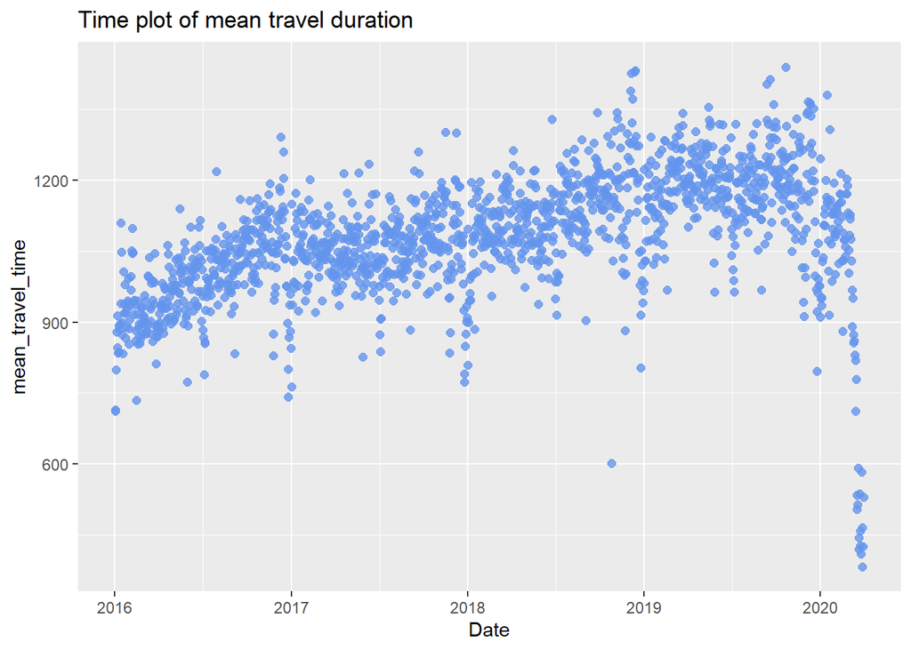

```r
ggplot(avg_times)+
  geom_point(aes(x=Date,y=mean_travel_time),color="cornflowerblue", size = 2, alpha=.8)+
  labs(title="Time plot of mean travel duration")
```

As we can observe here, the mean travel time decreases around the end of the year. And we can also see a very steep and uncharacteristic drop after February 2020 which is due to the effects of the pandemic. For the purpose of or project, we will only take data till January 2020 as the pandemic is a one time occurrence which can add bias to our forecasting.

```r
#Slicing the last 2 months of data
avg_times <- slice(avg_times,1:(n()-60))
```

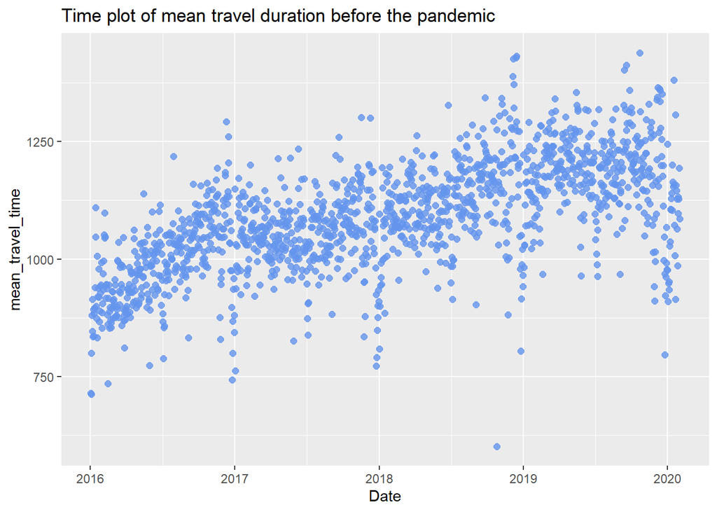

```r
ggplot(avg_times)+
  geom_point(aes(x=Date,y=mean_travel_time),color="cornflowerblue", size = 2, alpha=.8)+
  labs(title="Time plot of mean travel duration before the pandemic")
```

Here we can observe the mean travel time decreases around the end of each year and remains less till January of the new year.

## Summary statistics and Histogram

```r
summary(avg_times)
```

```
##       Date            mean_travel_time     day
##  Min.   :2016-01-02   Min.   : 602     Length:1489
##  1st Qu.:2017-01-08   1st Qu.:1015     Class :character
##  Median :2018-01-15   Median :1086     Mode  :character
##  Mean   :2018-01-15   Mean   :1089
##  3rd Qu.:2019-01-24   3rd Qu.:1169
##  Max.   :2020-01-31   Max.   :1439
```

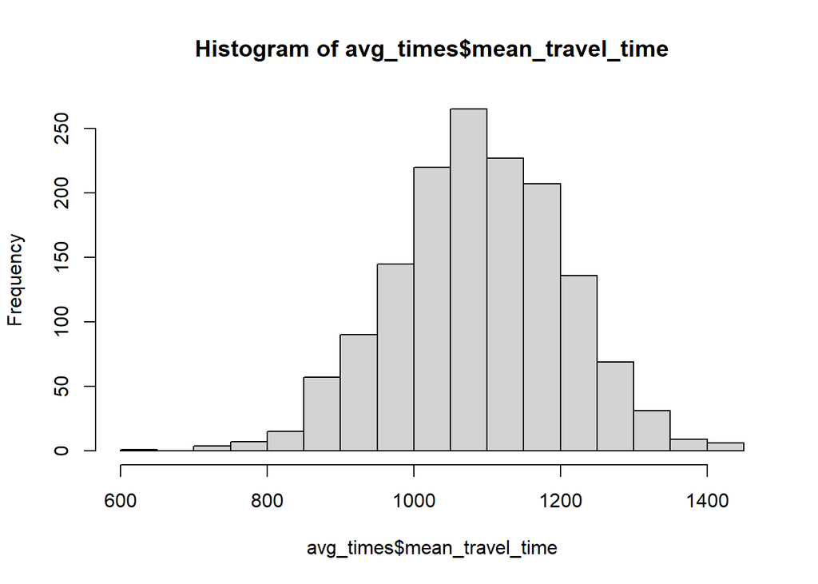

```r
hist(avg_times$mean_travel_time)
```

## Analyzing total number of Uber trips in San Francisco everyday from the central point of the city to all the destination zones.

```r
trip_count <- sanfranscico[,count_trips:= .N,by=Date]
trip_count <- trip_count %>% select(Date,count_trips) %>% distinct()
#Slicing last two months of data to exclude pandemic bias
trip_count <- slice(trip_count,1:(n()-60))
```

```r
trip_count <- trip_count %>% mutate(day=weekdays(Date))
```

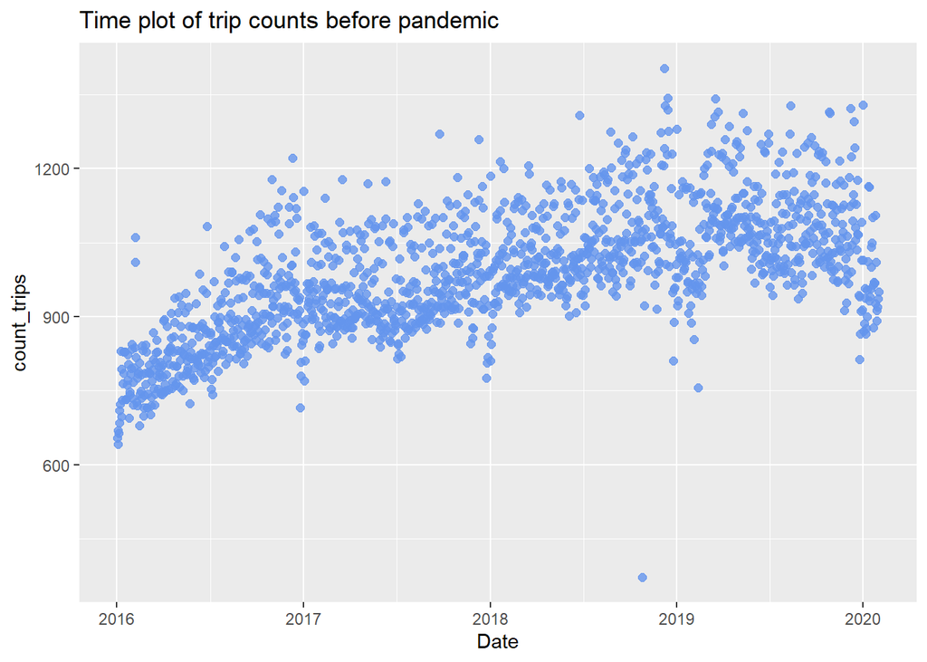

```r
ggplot(trip_count)+
  geom_point(aes(x=Date,y=count_trips),color="cornflowerblue", size = 2, alpha=.8)+
  labs(title = "Time plot of trip counts before pandemic")
```

```r
merged_data <- merge(avg_times,trip_count,by="Date")
```

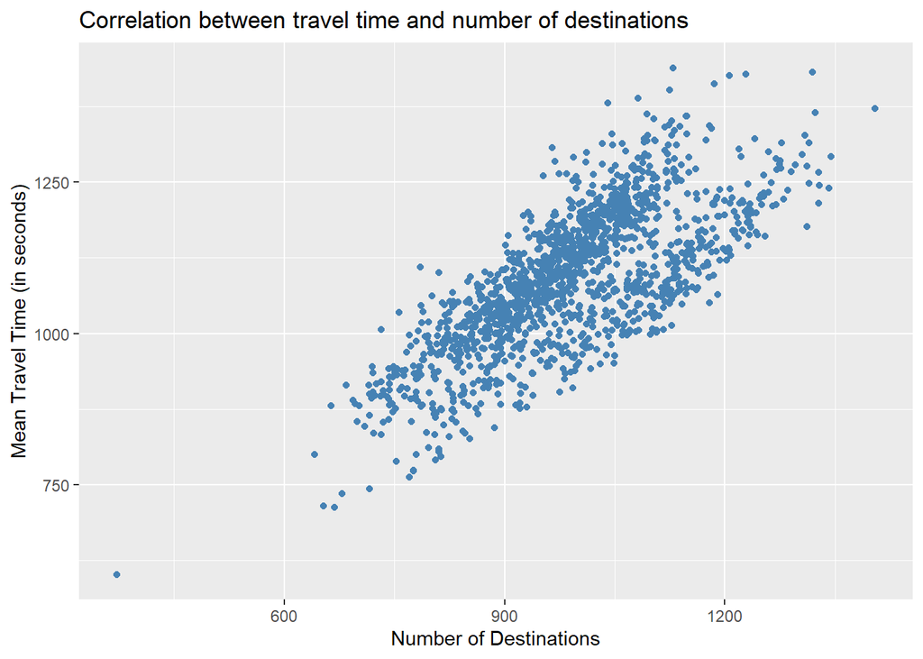

```r
ggplot(merged_data) +
  geom_point(aes(x=count_trips,y=mean_travel_time),color="steelblue") +
  labs(x="Number of Destinations",y="Mean Travel Time (in seconds)",title="Correlation between travel time and number of destinations")
```

As we can observe in the above plot, there is a linear relationship between number of destination zones and mean travel time because a higher number of trips could indicate more traffic which could in turn lead to higher travel times.

## Calculating weekly demand statistics

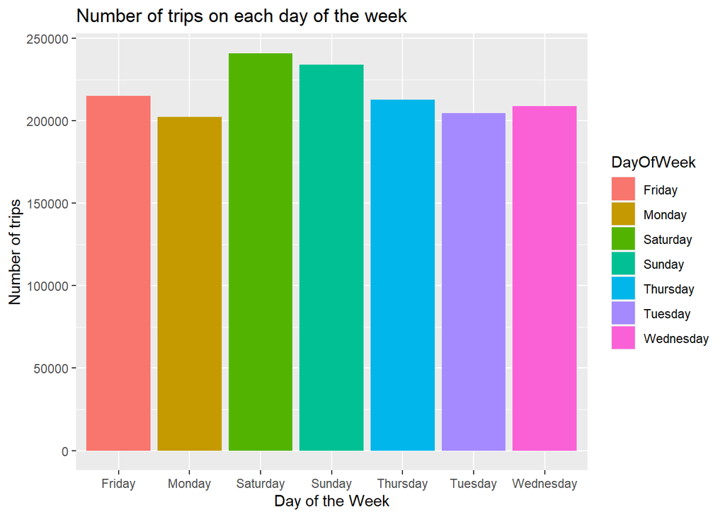

```r
week_stats <- sanfranscico %>% group_by(DayOfWeek) %>% summarise(count_trips = n())
ggplot(week_stats,aes(x=DayOfWeek,y=count_trips,fill=DayOfWeek,group=DayOfWeek))+
  geom_bar(stat="identity")+
  labs(title="Number of trips on each day of the week",x="Day of the Week",y="Number of trips")
```

We see the highest number of trips on weekends. There is not much difference among the other weekdays.

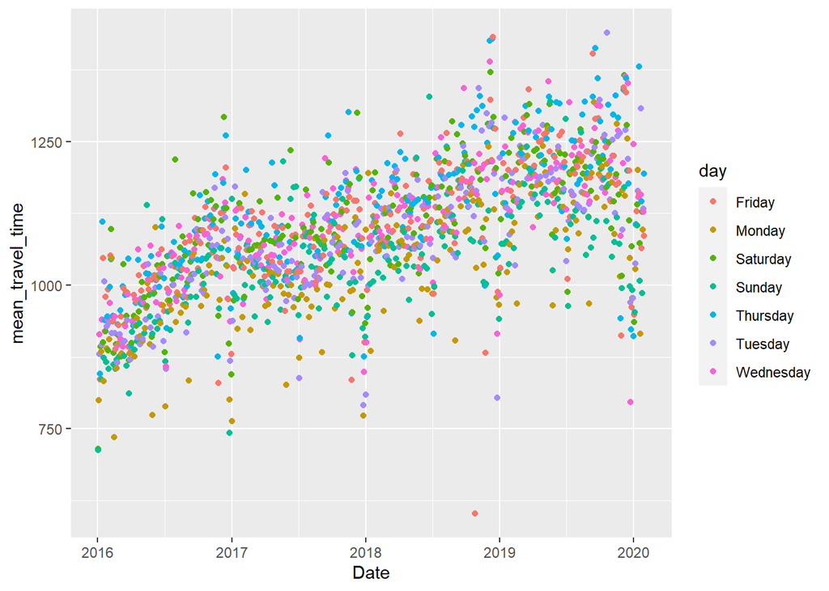

```r
ggplot(avg_times,aes(x=Date,y=mean_travel_time,color=day), size = 2, alpha=.8)+
  geom_point()+
  labs("Time plot of mean travel duration")
```

## Analyzing mean travel times faceted out by weekdays

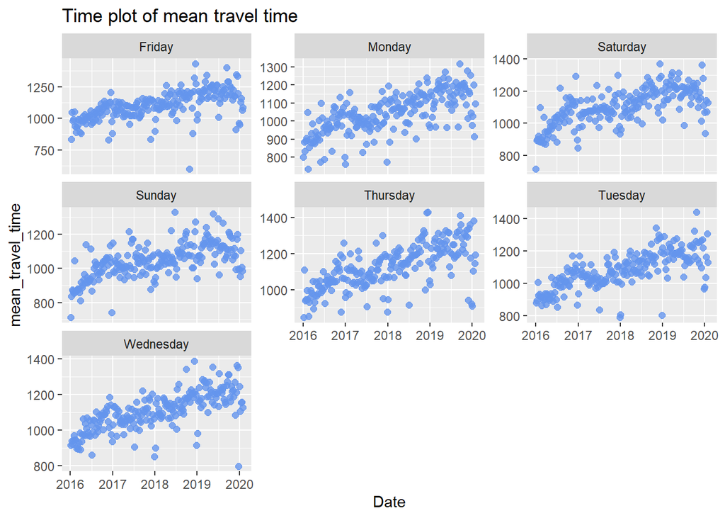

```r
ggplot(avg_times)+
  geom_point(aes(x=Date,y=mean_travel_time),color="cornflowerblue", size = 2, alpha=.8)+
  facet_wrap(~day, scales="free_y") +
  labs(title="Time plot of mean travel time")
```

## Analyzing daily trip counts facted out by weekdays

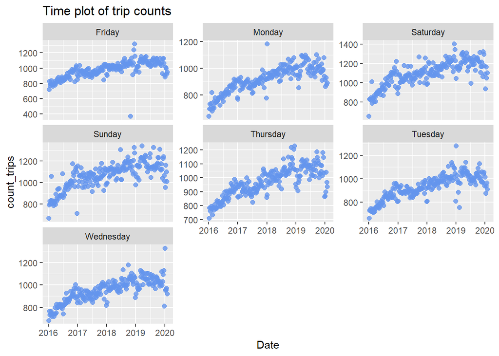

```r
ggplot(trip_count)+
  geom_point(aes(x=Date,y=count_trips),color="cornflowerblue", size = 2, alpha=.8)+
  facet_wrap(~day, scales="free_y") +
  labs(title="Time plot of trip counts")
```

Here we observe that the number of trips are usually highest on weekends and lesser on weekdays. This could be because lot of people might be going out on weekend.

```r
avg_times <-  avg_times %>% mutate(Date_parsed = date(Date)) %>% select(-Date)
avg_times_ts <- as_tsibble(avg_times,index=Date_parsed)
```

```r
avg_times_ts <- fill_gaps(avg_times_ts,mean_travel_time = mean(mean_travel_time))
```

## Performing Weekly and Yearly Seasonality

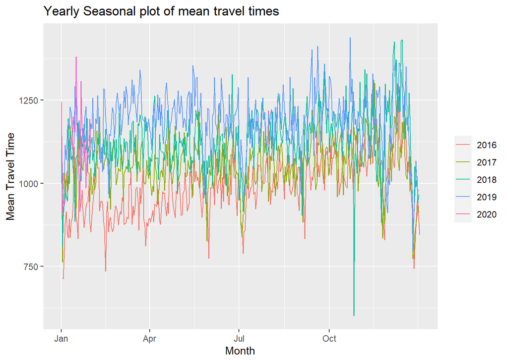

```r
avg_times_ts %>% gg_season(mean_travel_time) + labs(y="Mean Travel Time",x="Month",title="Yearly Seasonal plot of mean travel times")
```

We are seeing seasonal variations wherein there is a decrease in January and December in mean travel times.

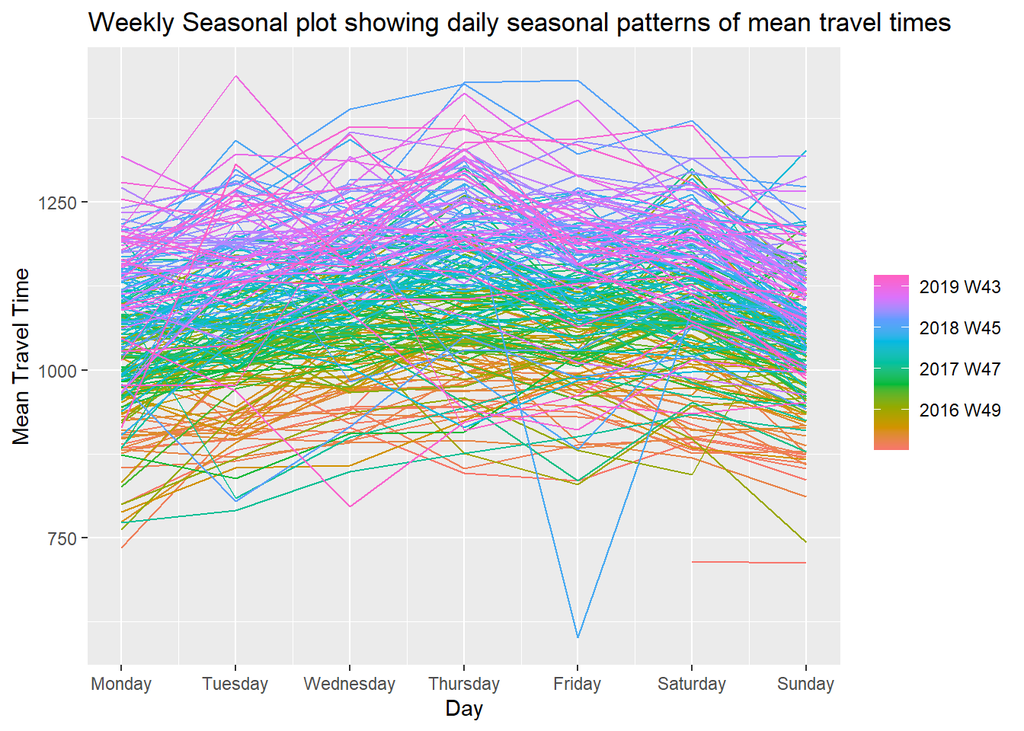

```r
avg_times_ts %>% gg_season(mean_travel_time,period="week") + labs(y="Mean Travel Time",x="Day",title="Weekly Seasonal plot showing daily seasonal patterns of mean travel times")
```

```r
trip_count <-  trip_count %>% mutate(Date_parsed = date(Date)) %>% select(-Date)
trip_count_ts <- tsibble(trip_count,index=Date_parsed)
trip_count_ts <- fill_gaps(trip_count_ts,.full = TRUE)
```

```r
trip_count_ts <- fill_gaps(trip_count_ts,.full = TRUE)
```

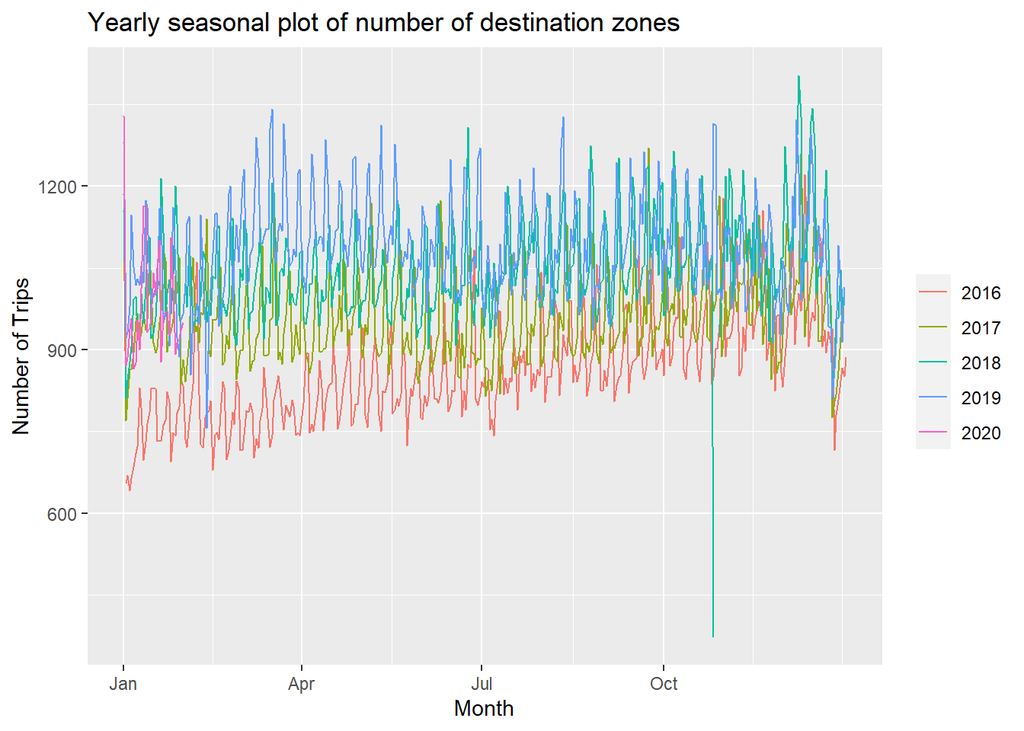

```r
trip_count_ts %>% gg_season(count_trips) + labs(y="Number of Trips",x="Month",title="Yearly seasonal plot of number of destination zones")
```

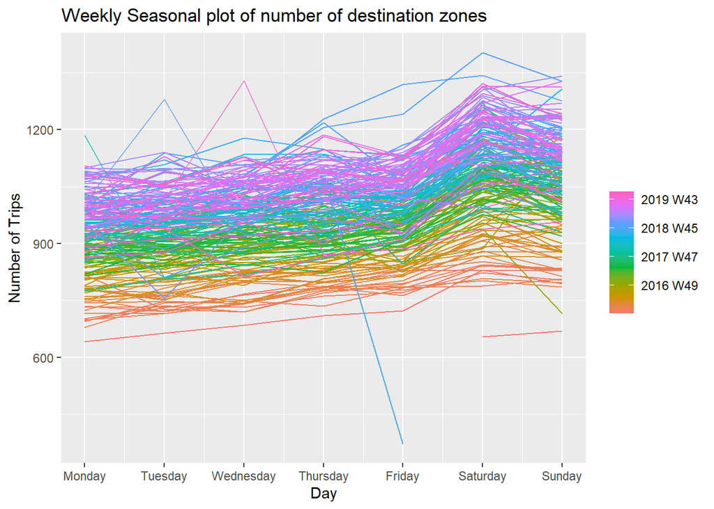

```r
trip_count_ts %>% gg_season(count_trips,period="week") + labs(y="Number of Trips",x="Day",title="Weekly Seasonal plot of number of destination zones")
```

## Lag Plots and ACF plots

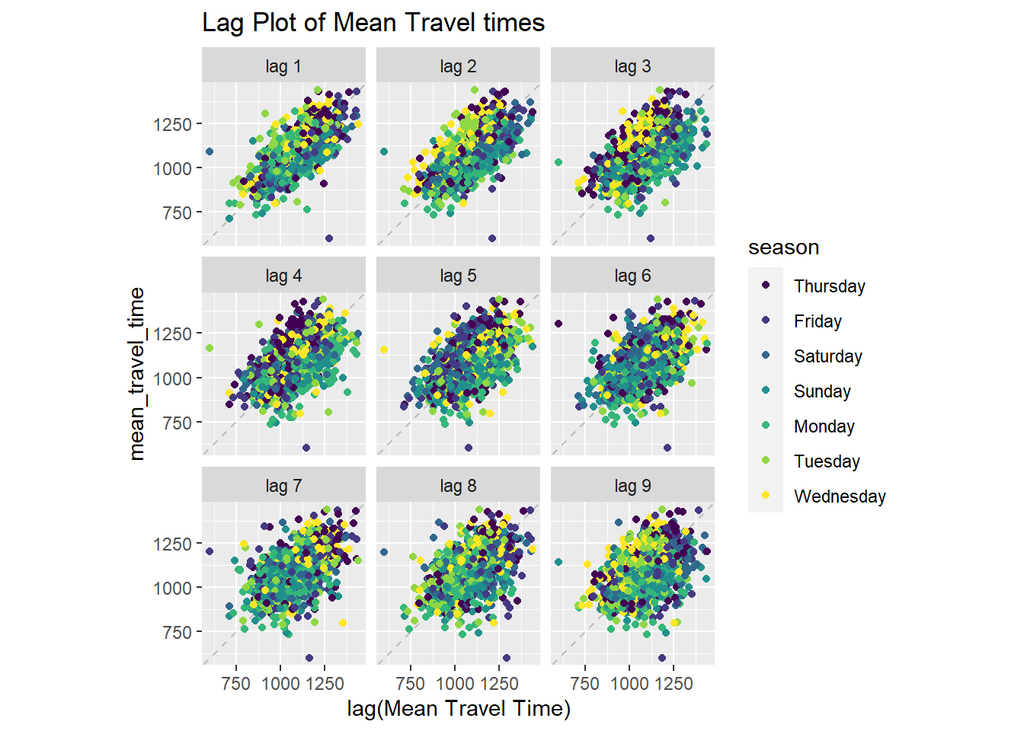

```r
avg_times_ts %>% gg_lag(mean_travel_time,geom="point")+
  labs(x="lag(Mean Travel Time)",title="Lag Plot of Mean Travel times")
```

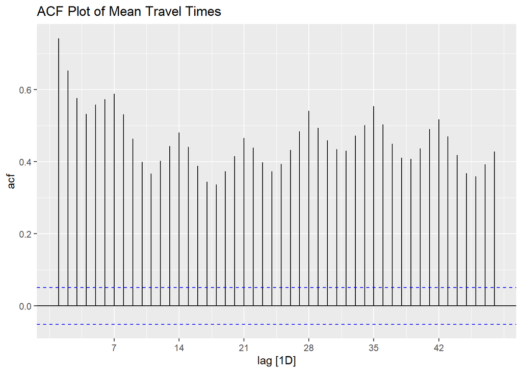

```r
avg_times_ts %>% ACF(mean_travel_time,lag_max=48) %>% autoplot() +
  labs(title="ACF Plot of Mean Travel Times")
```

Here we are seeing a scalloped shape because there is a weekly seasonality that can be observed. The strongest correlation can be seen among the starting two consecutive days.

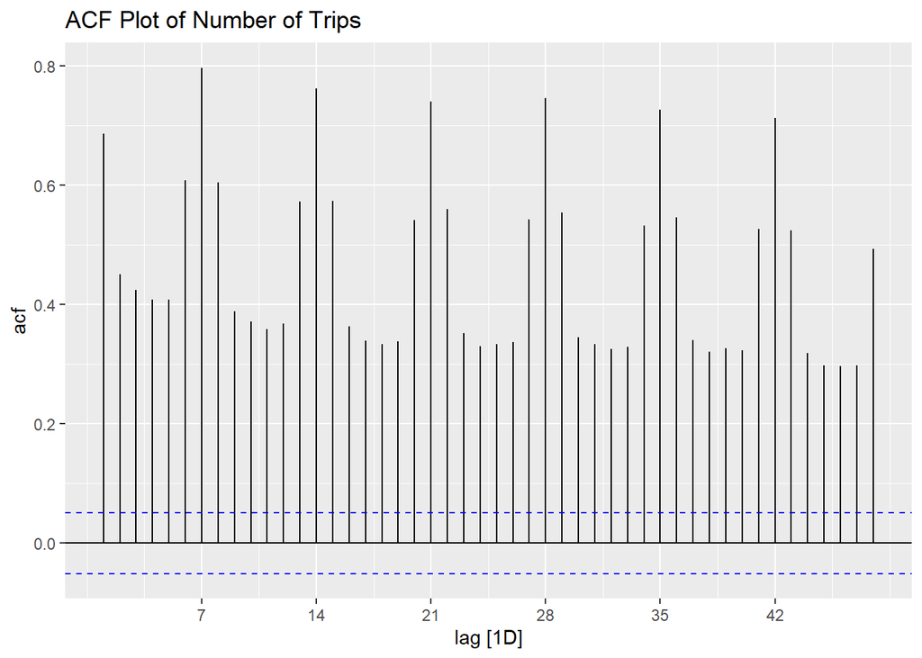

```r
trip_count_ts %>% ACF(count_trips,lag_max=48) %>% autoplot() +
  labs(title="ACF Plot of Number of Trips")
```

Even in this ACF plot, we are observing a very strong weekly seasonality in the data. So we can confirm that the number of trips on a certain day of the week are fairly predictable.

## Plotting 30 day moving average

```r
avg_times_ma <- avg_times_ts %>% mutate(
    `30-MA` = slider::slide_dbl(mean_travel_time, mean,
                .before = 15, .after = 14, .complete = TRUE)
  )
```

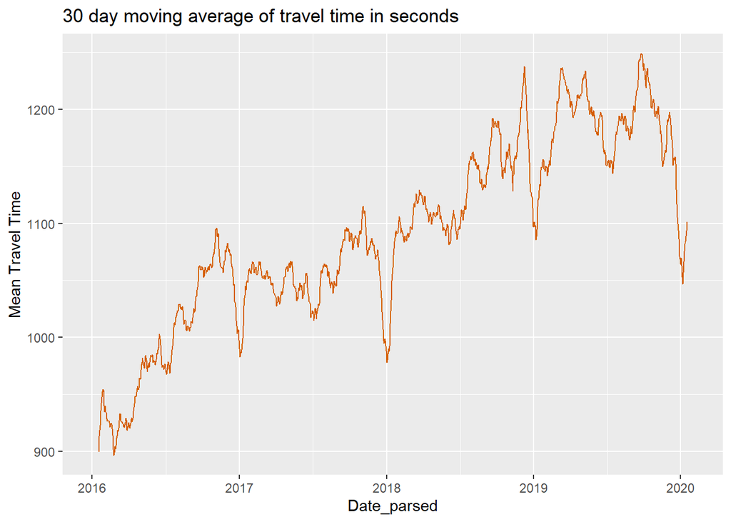

```r
ggplot(avg_times_ma) +
  geom_line(aes(x=Date_parsed,y = `30-MA`), colour = "#D55E00") +
  labs(y = "Mean Travel Time",
       title = "30 day moving average of travel time in seconds") +
  guides(colour = guide_legend(title = "series"))
```

Here we can see that the seasonality pattern that we identified in the previous plots wherein the mean travel time reduces around the end of each year and remains lesser till January is more clearly identifiable.

```r
trip_counts_ma <- trip_count_ts %>% mutate(
    `30-MA` = slider::slide_dbl(count_trips, mean,
                .before = 15, .after = 14, .complete = TRUE)
  )
```

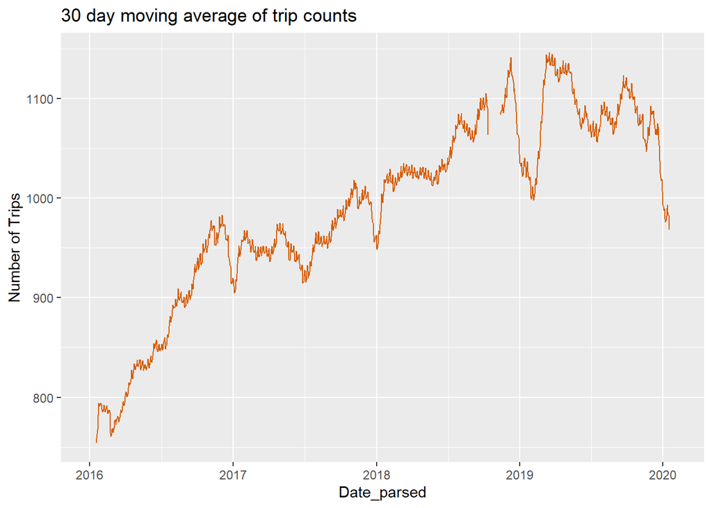

```r
ggplot(trip_counts_ma) +
  geom_line(aes(x=Date_parsed,y = `30-MA`), colour = "#D55E00") +
  labs(y = "Number of Trips",
       title = "30 day moving average of trip counts") +
  guides(colour = guide_legend(title = "series"))
```

We can observe the same seasonality pattern in this plot as well which also confirms that trip counts are correlated with mean travel time.

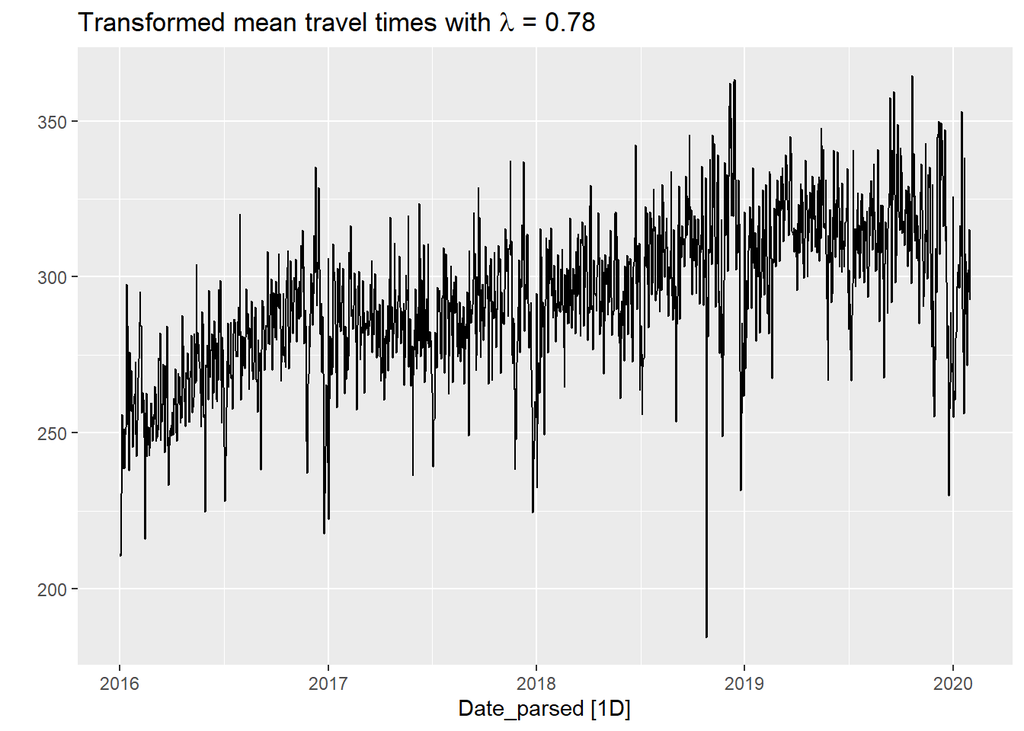

```r
lambda <- avg_times_ts %>%
  features(mean_travel_time, features = guerrero) %>%
  pull(lambda_guerrero)

avg_times_ts %>%
  autoplot(box_cox(mean_travel_time, lambda)) +
  labs(y = "",
       title = latex2exp::TeX(paste0(
         "Transformed mean travel times with $\\lambda$ = ",
         round(lambda,2))))
```

## Calculating Decomposition Features

```r
avg_times_ts %>% features(mean_travel_time,feat_stl)
```

```
## # A tibble: 1 × 9
##   trend_strength seaso…¹ seaso…² seaso…³ spiki…⁴ linea…⁵ curva…⁶ stl_e…⁷ stl_e…⁸
##            <dbl>   <dbl>   <dbl>   <dbl>   <dbl>   <dbl>   <dbl>   <dbl>   <dbl>
## 1          0.824   0.420       6       2    14.5   2860.   -568. -0.0742   0.128
## # … with abbreviated variable names ¹seasonal_strength_week,
## #   ²seasonal_peak_week, ³seasonal_trough_week, ⁴spikiness, ⁵linearity,
## #   ⁶curvature, ⁷stl_e_acf1, ⁸stl_e_acf10
```

```r
trip_count_ts %>% features(count_trips,feat_stl)
```

```
## # A tibble: 1 × 9
##   trend_strength seaso…¹ seaso…² seaso…³ spiki…⁴ linea…⁵ curva…⁶ stl_e…⁷ stl_e…⁸
##            <dbl>   <dbl>   <dbl>   <dbl>   <dbl>   <dbl>   <dbl>   <dbl>   <dbl>
## 1          0.881   0.790       1       0    27.4   2534.   -483. -0.0673   0.117
## # … with abbreviated variable names ¹seasonal_strength_week,
## #   ²seasonal_peak_week, ³seasonal_trough_week, ⁴spikiness, ⁵linearity,
## #   ⁶curvature, ⁷stl_e_acf1, ⁸stl_e_acf10
```

# Time series decompositon of mean travel time

## Classical multiplicative Decomposition

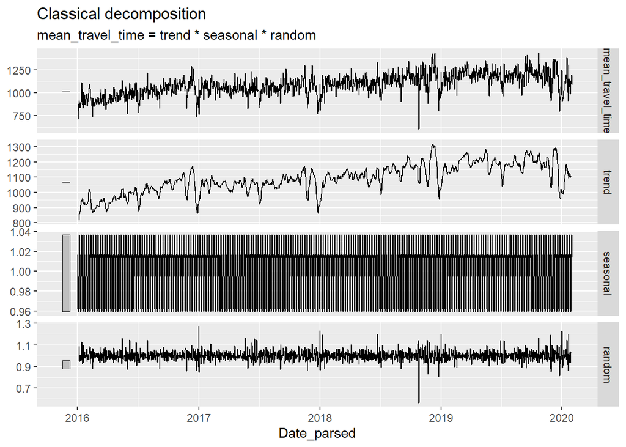

```r
dcmp <- avg_times_ts %>%  model(classical_decomposition(mean_travel_time,type="multiplicative"))

components(dcmp) %>% autoplot()
```

Here we are not seeing a very good decompositon as there is still a yearly seasonal component left in our trend component.

## STL Decomposition

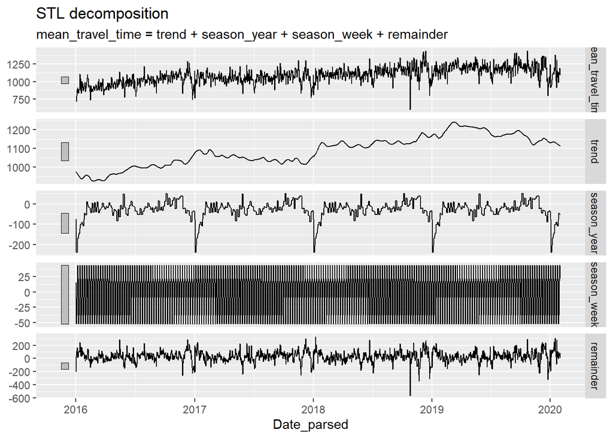

```r
library(feasts)

dcmp <- avg_times_ts %>% model(stl=STL(mean_travel_time ~ trend(window=31) +
                                          season(window="periodic"),
                                        robust=TRUE))

components(dcmp) %>% autoplot()
```

```r
dcmp <- avg_times_ts %>% model(stlf=decomposition_model(STL(log(mean_travel_time) ~ trend(window=30),
                                        robust=TRUE),
                               SNAIVE(season_adjust)))
```

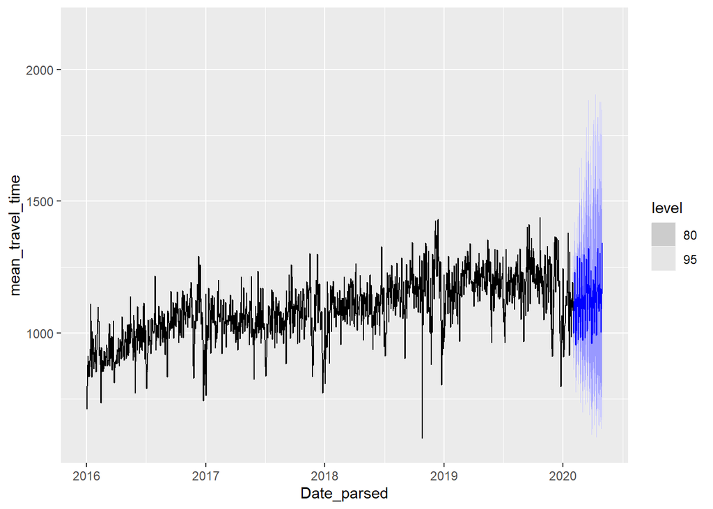

```r
dcmp %>% forecast(h=90) %>% autoplot(avg_times_ts)
```

Here we are observing a good time series decomposition because there is a seperate seasonal component for yearly seasonality and weekly seasonality.

[figure not shown]

```r
avg_times_ts %>% model(SNAIVE(log(mean_travel_time))) %>% forecast(h=365) %>% autoplot(avg_times_ts)
```

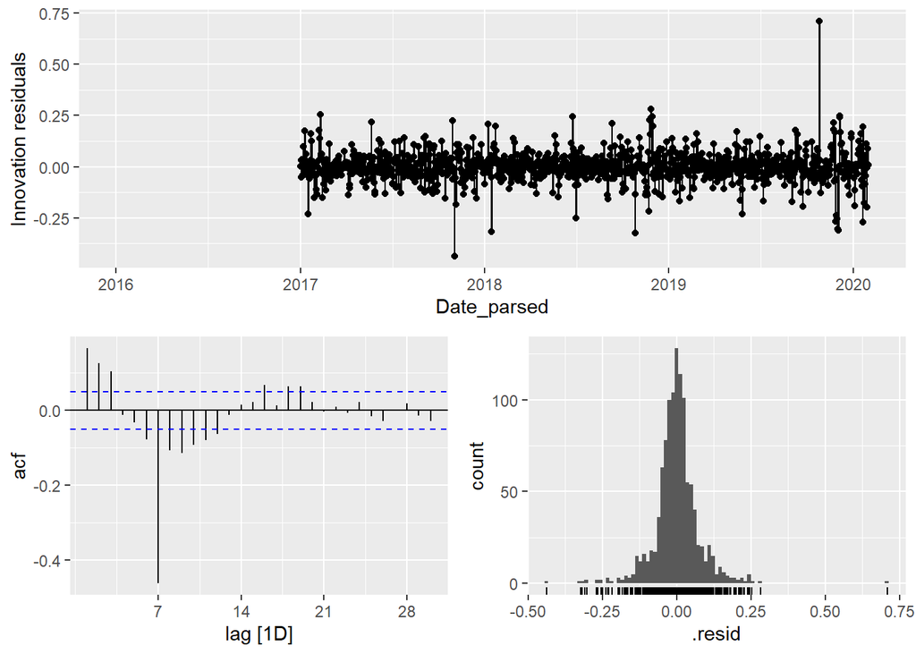

```r
dcmp %>% gg_tsresiduals()
```

## Running STL decomposition on a training set

```r
train <- slice(avg_times,1:(n()-60))
train <- as_tsibble(train,index=Date_parsed)
train <- fill_gaps(train,mean_travel_time = mean(mean_travel_time))
```

```r
train_dcmp <- train %>% model(stlf=decomposition_model(STL(log(mean_travel_time) ~ trend(window=31),
                                        robust=TRUE),
                               NAIVE(season_adjust)))
```

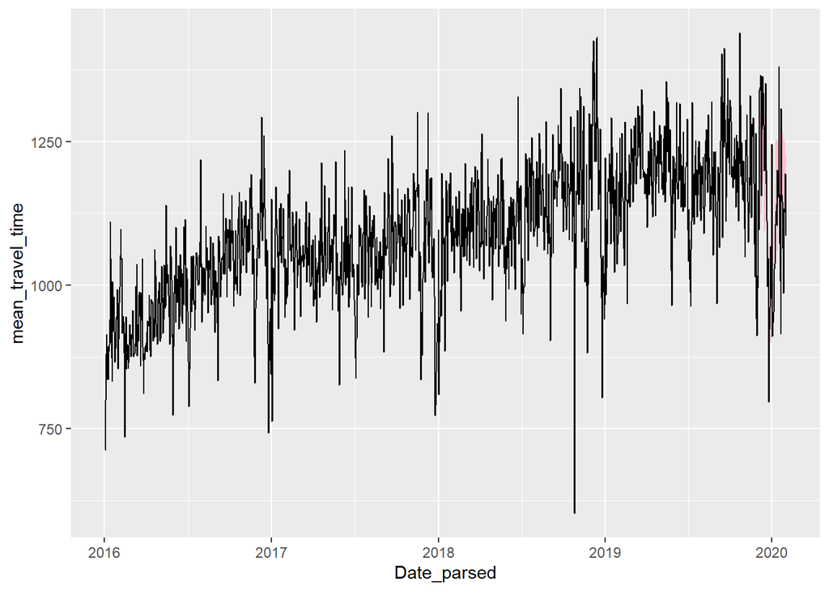

```r
train_dcmp %>% forecast(h=60) %>% autoplot(avg_times_ts,level=NULL,color="pink")
```

```r
train_fc <- train_dcmp %>% forecast(h=60)
accuracy(train_fc,avg_times_ts)
```

```
## # A tibble: 1 × 10
##   .model .type    ME  RMSE   MAE   MPE  MAPE  MASE RMSSE  ACF1
##   <chr>  <chr> <dbl> <dbl> <dbl> <dbl> <dbl> <dbl> <dbl> <dbl>
## 1 stlf   Test  -11.2  93.3  75.3 -1.59  6.70  1.07 0.954 0.313
```

## Forecasting with STL decomposition

```r
fit_dcmp_new <- avg_times_ts %>%
  model(stlf = decomposition_model(
    STL(mean_travel_time ~ trend(window = 7), robust = TRUE),
    NAIVE(season_adjust)))
```

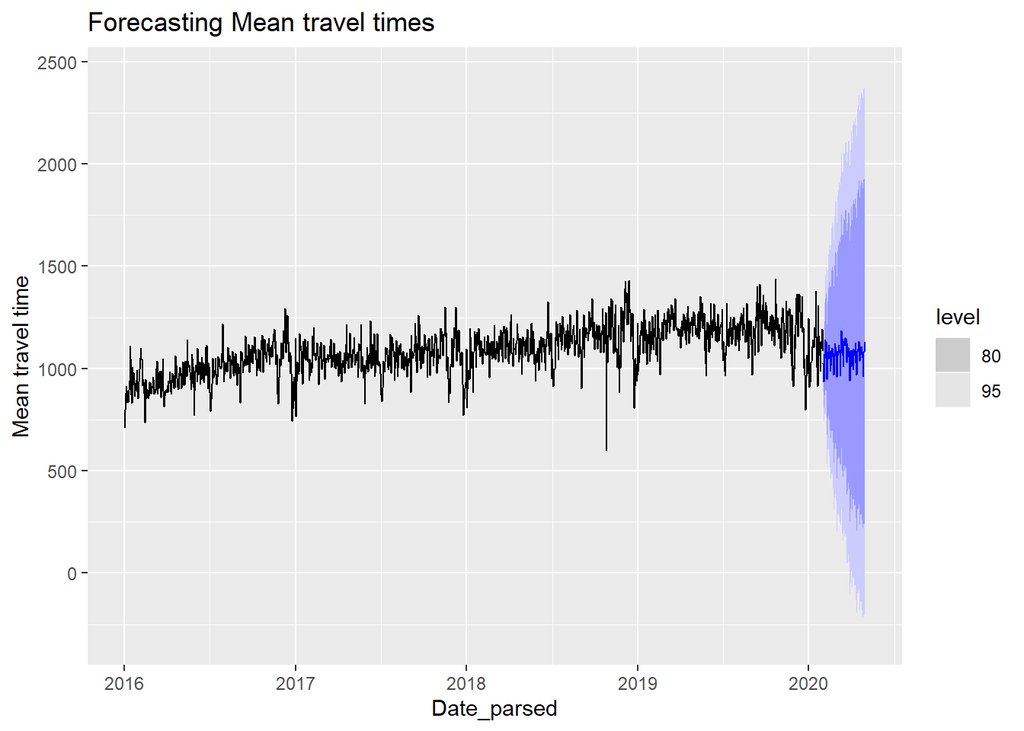

```r
fit_dcmp_new %>%
  forecast(h=90) %>%
  autoplot(avg_times_ts)+
  labs(y = "Mean travel time",
       title = "Forecasting Mean travel times")
```

```r
predictions <- fit_dcmp_new %>%
  forecast(h=90) %>% hilo()
```

# ETS Modelling

```r
fit_ets <- train %>% model(additive = ETS(mean_travel_time ~ error("A") + trend("A") +
                                                season("A")),
    hw = ETS(mean_travel_time ~ error("M") + trend("Ad") +
                                                season("M")))

fit_ets_fc <- fit_ets %>% forecast(h=60)
```

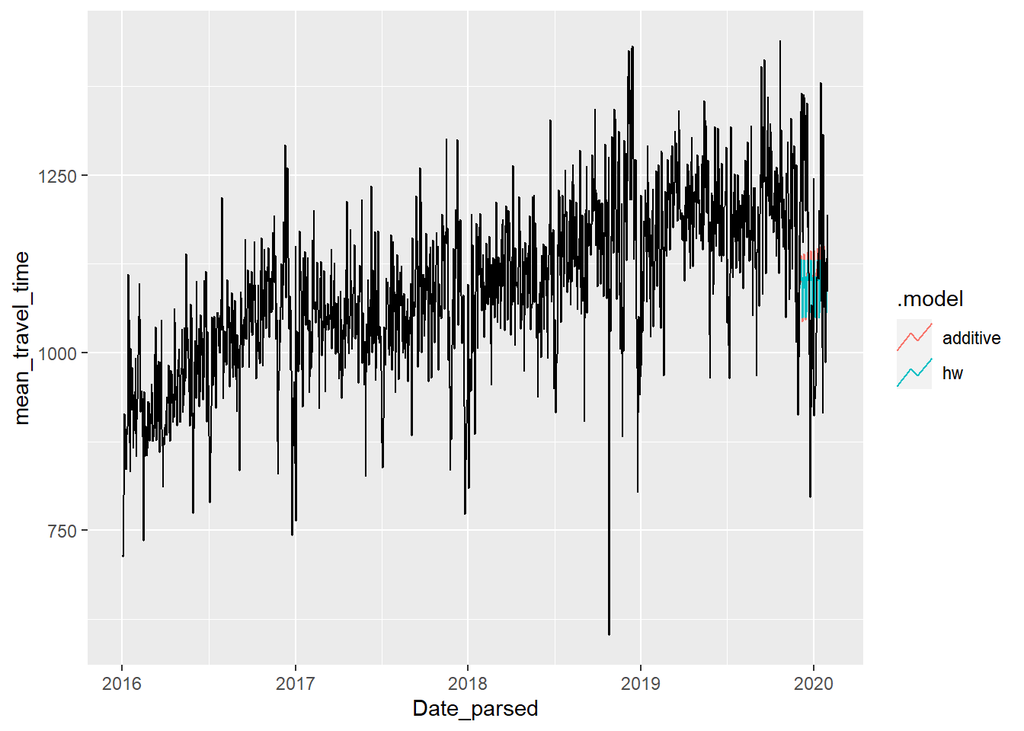

```r
fit_ets_fc %>% autoplot(avg_times_ts,level=NULL)
```

## Performance Statistics

```r
report(fit_ets)
```

```
## # A tibble: 2 × 9
##   .model       sigma2 log_lik    AIC   AICc    BIC   MSE  AMSE     MAE
##   <chr>         <dbl>   <dbl>  <dbl>  <dbl>  <dbl> <dbl> <dbl>   <dbl>
## 1 additive 4309.      -11181. 22386. 22386. 22449. 4276. 5100. 47.9
## 2 hw          0.00375 -11195. 22416. 22416. 22485. 4254. 5087.  0.0442
```

From the AIC and BIC values, it can be observed that ETS is not performing well.

## Decomposition

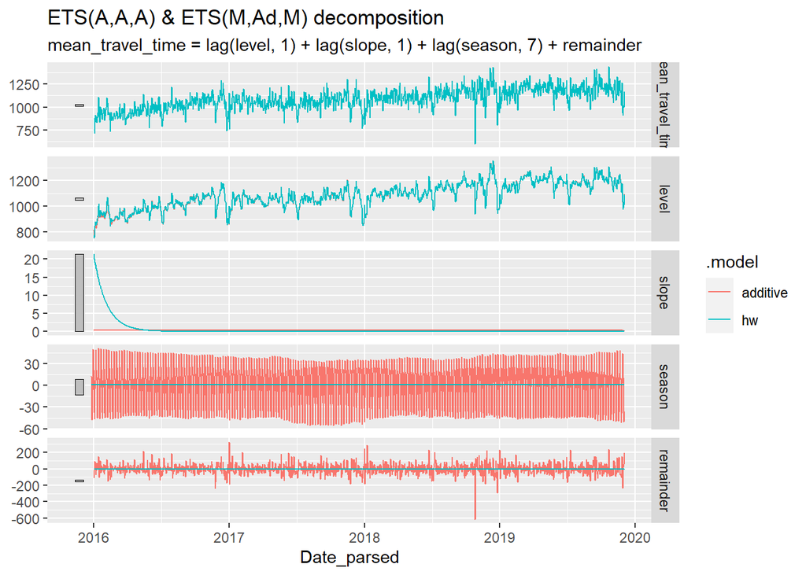

```r
components(fit_ets) %>% autoplot()
```

# Transformations for weekly and monthly data

```r
avg_times <- avg_times %>% mutate(month=yearmonth(Date_parsed))

avg_times_mo <- avg_times %>% group_by(month) %>% summarise(mean_travel_time = mean(mean_travel_time))

avg_times_mo <- as_tsibble(avg_times_mo,index=month)

avg_times_mo <- fill_gaps(avg_times_mo,mean_travel_time = mean(mean_travel_time))


avg_times <- avg_times %>% mutate(week=yearweek(Date_parsed))

avg_times_week <- avg_times %>% group_by(week) %>% summarise(mean_travel_time = mean(mean_travel_time))

avg_times_week <- as_tsibble(avg_times_week,index=week)

avg_times_week <- fill_gaps(avg_times_week,mean_travel_time = mean(mean_travel_time))
```

```
## Plot variable not specified, automatically selected `.vars = mean_travel_time`
```

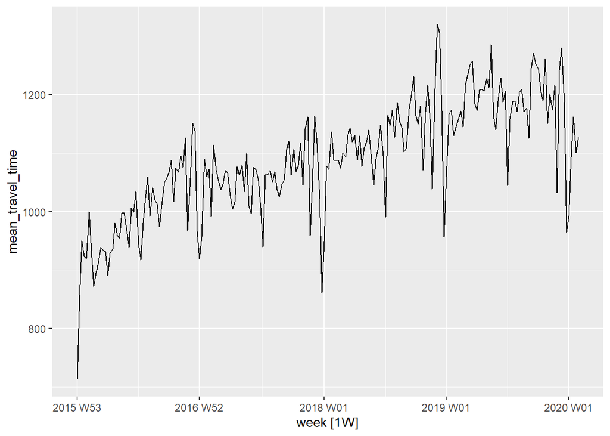

```r
autoplot(avg_times_week)
```

# Stationarity and differencing

```r
avg_times_week %>% features(log(mean_travel_time),unitroot_nsdiffs)
```

```
## # A tibble: 1 × 1
##   nsdiffs
##     <int>
## 1       1
```

Here we can observe through unit root test that the weekly transformed data requires one order of seasonal differencing.

```r
avg_times_week  %>% mutate(log_travel_time =difference(log(mean_travel_time),52)) %>% features(log_travel_time,unitroot_ndiffs)
```

```
## # A tibble: 1 × 1
##   ndiffs
##    <int>
## 1      1
```

```r
avg_times_week %>% mutate(doubly_diff_travel_time = difference(difference(log(mean_travel_time),52))) %>%
  features(doubly_diff_travel_time,unitroot_kpss)
```

```
## # A tibble: 1 × 2
##   kpss_stat kpss_pvalue
##       <dbl>       <dbl>
## 1    0.0796         0.1
```

Here we can see that the KPSS test is giving a high p value which means our first order differencing and first order seasonal differencing is correct.

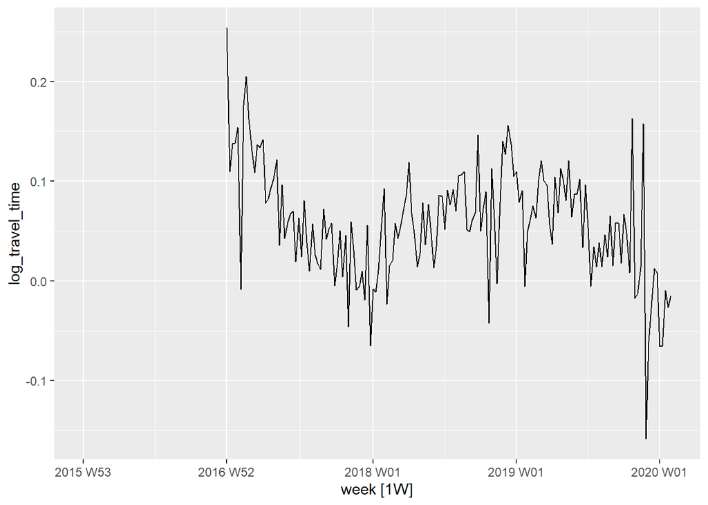

```r
avg_times_week <- avg_times_week %>% mutate(log_travel_time = difference(log(mean_travel_time),52))

autoplot(avg_times_week,log_travel_time)
```

```r
avg_times_week <- avg_times_week %>% mutate(doubly_diff_travel_time = difference(difference(log(mean_travel_time),52)))
```

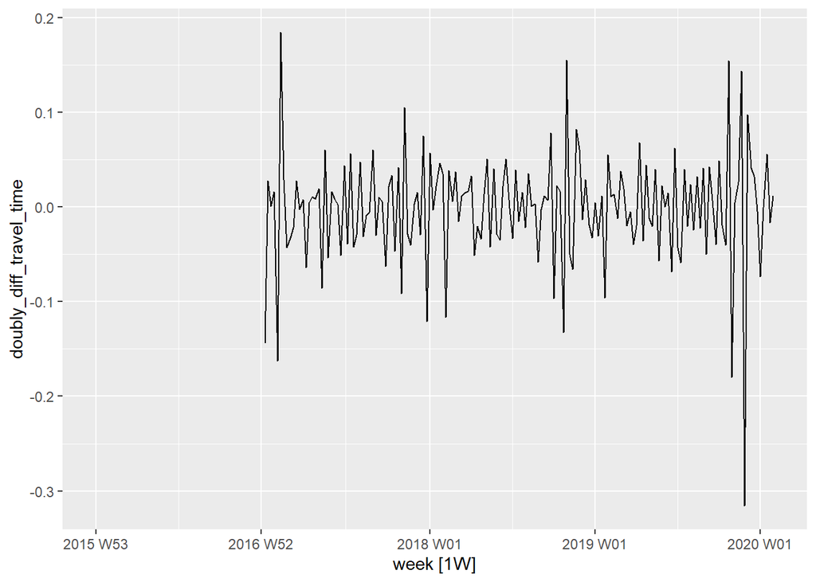

```r
autoplot(avg_times_week,doubly_diff_travel_time)
```